# Question

Para ambientar musicalmente una reunión, se cuenta con tres CDs, cada uno de ellos tiene canciones de salsa (S) y merengue (M). ¿Cuál de los siguientes diagramas representa la situación de seleccionar al azar una canción del CD1, luego una del CD2 y finalmente una del CD3?

**Opción A:**

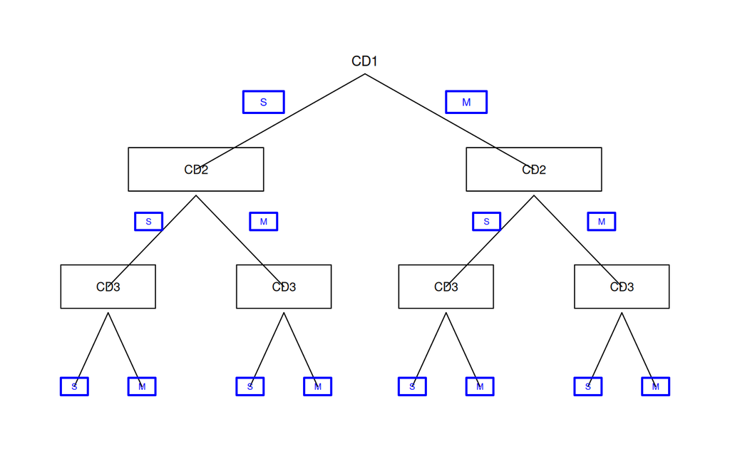

**Opción B:**

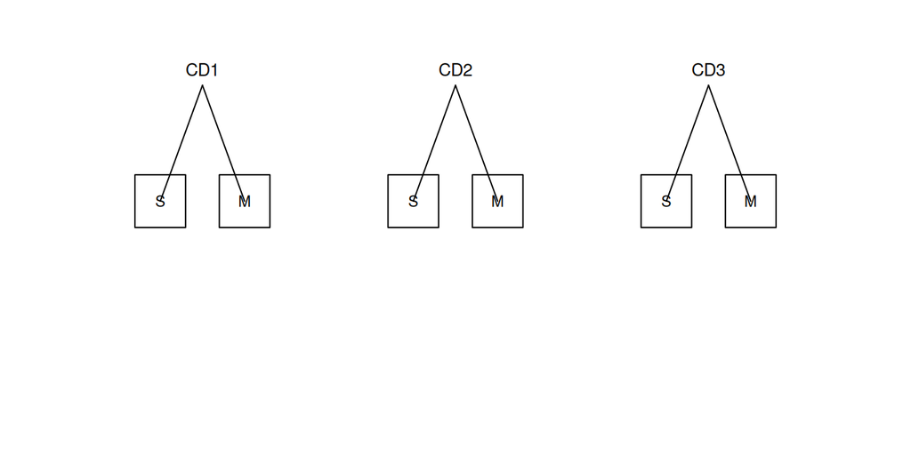

**Opción C:**

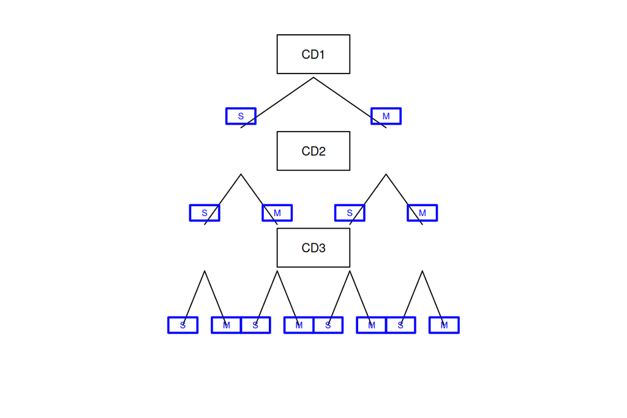

**Opción D:**

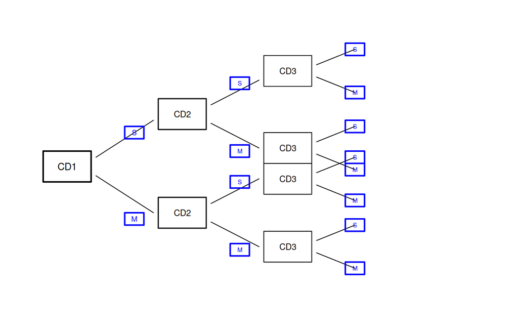

## Answerlist

- Opción A
- Opción B
- Opción C
- Opción D

# Solution

El diagrama debe representar la **secuencia de decisiones** al seleccionar una canción de cada CD en orden: primero del CD1, luego del CD2, y finalmente del CD3.

**Estructura correcta (Opción D):**

1. **CD1** (inicio): 2 opciones (S o M)
2. **CD2** (segundo nivel): Desde cada opción de CD1, se ramifican 2 nuevas opciones → 4 ramas totales
3. **CD3** (tercer nivel): Desde cada opción de CD2, se ramifican 2 nuevas opciones → 8 resultados finales

**Total de combinaciones:** 2 × 2 × 2 = **8 combinaciones posibles**

**Principio clave:** En un proceso secuencial de selección, cada etapa debe representarse como un nivel en el árbol, y todas las ramas deben desarrollarse completamente antes de pasar al siguiente nivel.

## Answerlist

# Meta-information

extype: schoice exsolution: 0001 exname: diagrama_arbol_seleccion_canciones exshuffle: FALSE